# Introduction to single-cell reference mapping

# 1 Dataset preprocessing

出于本示例的目的，我们选择了通过四种技术产生的人类胰岛细胞数据集，即 CelSeq (GSE81076)、CelSeq2 (GSE85241)、Fluidigm C1 (GSE86469), and SMART-Seq2 (E-MTAB-5061)。为方便起见，我们通过 SeuratData 包分发此数据集。metadata 包含四个数据集中每个细胞的技术（`tech` column）和细胞类型注释（`celltype` column）。

```r
library(Seurat)
library(SeuratData)
```

```r
InstallData("panc8")
```

为了构建 reference，我们将识别各个数据集之间的“anchors”。首先，我们将组合对象拆分为一个 list，每个数据集作为一个元素（这只是必要的，因为数据被捆绑在一起以便于分发）。

```r
data("panc8")
pancreas.list <- SplitObject(panc8, split.by = "tech")
pancreas.list <- pancreas.list[c("celseq", "celseq2", "fluidigmc1", "smartseq2")]
```

在找到anchors之前，我们执行标准预处理（log-normalization），并为每个anchors单独识别可变特征。请注意，Seurat 实现了一种改进的基于方差稳定变换（“vst”）的变量特征选择方法

```r
for (i in 1:length(pancreas.list)) {
    pancreas.list[[i]] <- NormalizeData(pancreas.list[[i]], verbose = FALSE)
    pancreas.list[[i]] <- FindVariableFeatures(pancreas.list[[i]], selection.method = "vst", nfeatures = 2000, verbose = FALSE)
}
```

# 2 Integration of 3 pancreatic islet cell datasets

接下来，我们使用 FindIntegrationAnchors() 函数识别anchors，该函数将 Seurat 对象列表作为输入。在这里，我们将其中三个对象集成到一个参考中（稍后我们将在本小插图中使用第四个对象作为查询数据集来演示映射）。  
我们在这里使用所有默认参数来识别anchors，包括数据集的“维度”（30；随意尝试在很宽的范围内更改此参数，例如在 10 到 50 之间）。

```r
reference.list <- pancreas.list[c("celseq", "celseq2", "smartseq2")]
pancreas.anchors <- FindIntegrationAnchors(object.list = reference.list, dims = 1:30)
```

然后我们将这些锚点传递给 IntegrateData() 函数，该函数返回一个 Seurat 对象。  
返回的对象将包含一个新的 Assay，其中包含所有细胞的集成（或“批量校正”）表达矩阵，使它们能够被联合分析。

```r
pancreas.integrated <- IntegrateData(anchorset = pancreas.anchors, dims = 1:30)
```

运行 IntegrateData() 后，Seurat 对象将包含一个带有integrated表达矩阵的新 Assay。 请注意，原始（未校正的值）仍存储在“RNA”测定中的对象中，因此您可以来回切换。  
然后我们可以使用这个新的integrated矩阵进行下游分析和可视化。在这里，我们scale integrated 数据，运行 PCA，并使用 UMAP 可视化结果。integrated的数据集按细胞类型而不是技术进行聚类。

```r
library(ggplot2)
library(cowplot)
library(patchwork)
# switch to integrated assay. The variable features of this assay are automatically set during
# IntegrateData
DefaultAssay(pancreas.integrated) <- "integrated"
# Run the standard workflow for visualization and clustering
pancreas.integrated <- ScaleData(pancreas.integrated, verbose = FALSE)
pancreas.integrated <- RunPCA(pancreas.integrated, npcs = 30, verbose = FALSE)
pancreas.integrated <- RunUMAP(pancreas.integrated, reduction = "pca", dims = 1:30, verbose = FALSE)
```

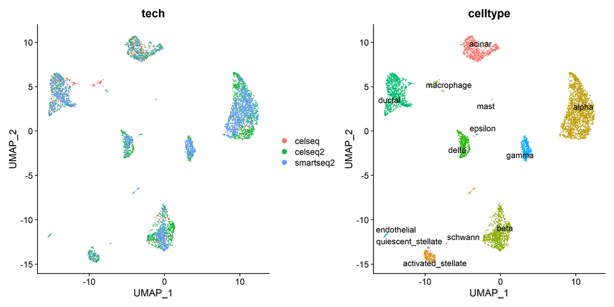

```r
p1 <- DimPlot(pancreas.integrated, reduction = "umap", group.by = "tech")
p2 <- DimPlot(pancreas.integrated, reduction = "umap", group.by = "celltype", label = TRUE, repel = TRUE) +
    NoLegend()
p1 + p2
```

# 3 Cell type classification using an integrated reference

Seurat 还支持将 reference 数据（或 meta data）投射到 query 对象上。虽然许多方法是保守的（两个过程都从识别anchors开始），但数据transfer和integration之间有两个重要区别：  
1.In data transfer, Seurat 不会更正或修改query表达数据。  
2.In data transfer, Seurat 有一个选项（默认设置）将 reference 的 PCA 结构投射到 query 上，而不是使用 CCA 学习联合结构。我们通常建议在 scRNA-seq 数据集之间投射数据时使用此选项。  
找到 anchors 后，我们使用 `TransferData()` 函数根据 reference 数据（参考细胞类型标签的向量）对 query cells 进行分类。`TransferData()` 返回一个包含预测 ID 和预测分数的矩阵，我们可以将其添加到 query metadata 中。

```r
pancreas.query <- pancreas.list[["fluidigmc1"]]
pancreas.anchors <- FindTransferAnchors(reference = pancreas.integrated, query = pancreas.query,
    dims = 1:30, reference.reduction = "pca")
predictions <- TransferData(anchorset = pancreas.anchors, refdata = pancreas.integrated$celltype,
    dims = 1:30)
pancreas.query <- AddMetaData(pancreas.query, metadata = predictions)
```

因为我们有来自完整integrated分析的原始标签注释，所以我们可以评估我们预测的细胞类型注释与完整参考的匹配程度。在这个例子中，我们发现细胞类型分类的一致性很高，超过 96% 的细胞被正确标记。

```r
pancreas.query$prediction.match <- pancreas.query$predicted.id == pancreas.query$celltype
table(pancreas.query$prediction.match)
```

```
FALSE  TRUE
   21   617
```

```r
table(pancreas.query$predicted.id)
```

```
            acinar activated_stellate              alpha               beta
                22                 17                253                256
             delta             ductal        endothelial              gamma
                22                 30                 12                 18
        macrophage               mast            schwann
                 1                  2                  5
```

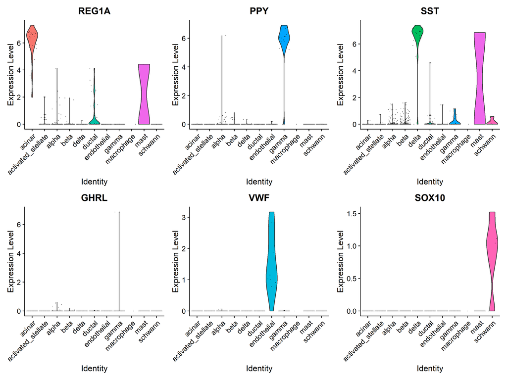

```r
VlnPlot(pancreas.query, c("REG1A", "PPY", "SST", "GHRL", "VWF", "SOX10"), group.by = "predicted.id")
```

# 4 Unimodal UMAP Projection

在 Seurat v4 中，我们还启用了将query投影到reference UMAP 结构上。这可以通过计算reference UMAP 模型然后调用 `MapQuery()` 而不是 `TransferData()` 来实现。

```r
pancreas.integrated <- RunUMAP(pancreas.integrated, dims = 1:30, reduction = "pca", return.model = TRUE)
pancreas.query <- MapQuery(anchorset = pancreas.anchors, reference = pancreas.integrated, query = pancreas.query,
    refdata = list(celltype = "celltype"), reference.reduction = "pca", reduction.model = "umap")
```

我们现在可以在reference旁边可视化query cells。

```r
p1 <- DimPlot(pancreas.integrated, reduction = "umap", group.by = "celltype", label = TRUE, label.size = 3,
    repel = TRUE) + NoLegend() + ggtitle("Reference annotations")
p2 <- DimPlot(pancreas.query, reduction = "ref.umap", group.by = "predicted.celltype", label = TRUE,
    label.size = 3, repel = TRUE) + NoLegend() + ggtitle("Query transferred labels")
```

[output not shown]

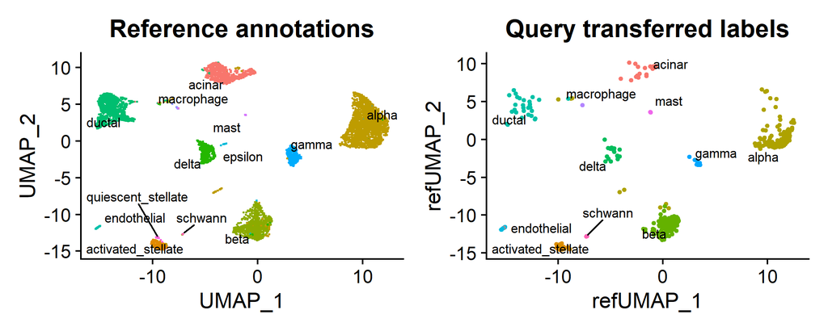

```r
p1 + p2
```